# Mapping BLS Data

Kris Eberwein

2022-09-15

## Mapping County Data

County data mapped on a national scale can sometimes be difficult to see. The `get_bls_county()` and `bls_map_county()` functions both have arguments that will accommodate data and maps for specific states or groups of states.

The example below shows the most recent unemployment rates for Florida.

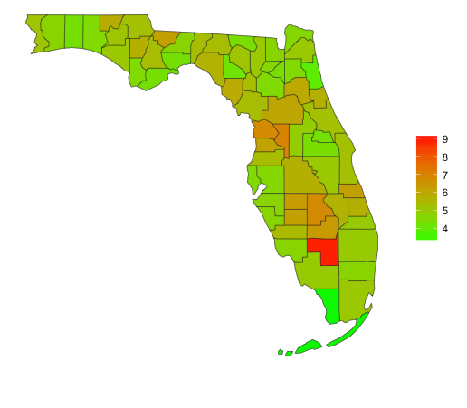

```r
library(blscrapeR)
df <- get_bls_county(stateName = "Florida")

map_bls(map_data=df, fill_rate = "unemployed_rate",
               stateName = "Florida")
```

Also, the states can be called together to form larger districts. Below is an example of the most recent unemployment rates for the southeastern states of Florida, Georgia and Alabama.

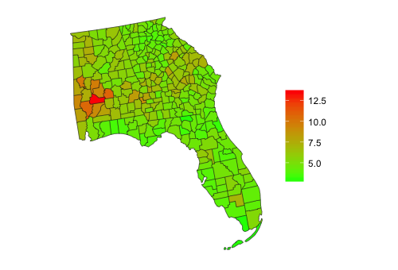

```r
# Map the unemployment rate for the Southeastern United States.
df <- get_bls_county(stateName = c("Florida", "Georgia", "Alabama"))

map_bls(map_data=df, fill_rate = "unemployed_rate", projection = "lambert",
               stateName = c("Florida", "Georgia", "Alabama"))
```

## Build Your Own Maps

If you don’t like any of the pre-fabricated maps, that’s alright because `blscrapeR` provides the fortified map data, which includes `longitude`, `latitude` and `FIPS` codes. This data set is suitable for any kind of `ggplot2` map you can think of.

First, call the internal map data and have a look:

```r
library(blscrapeR)
us_map <- county_map_data
head(us_map)
```

```
##      long      lat order  hole piece   group    id
## 1 1225889 -1275020     1 FALSE     1 01001.1 01001
## 2 1244873 -1272331     2 FALSE     1 01001.1 01001
## 3 1244129 -1267515     3 FALSE     1 01001.1 01001
## 4 1272010 -1262889     4 FALSE     1 01001.1 01001
## 5 1276797 -1295514     5 FALSE     1 01001.1 01001
## 6 1272367 -1296730     6 FALSE     1 01001.1 01001
```

Next, produce your custom map:

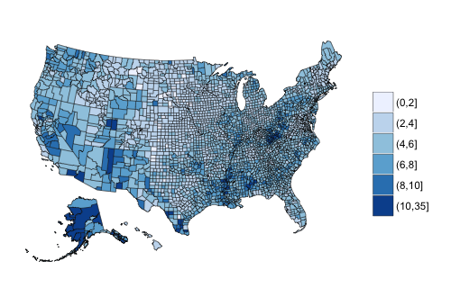

```r
library(blscrapeR)
library(ggplot2)
# Get the most recent unemployment rate for each county on a national level.
df <- get_bls_county()
# Get map data
us_map <- county_map_data

# Insert larger breaks in unemployment rates
df$rate_d <- cut(df$unemployed_rate, breaks = c(seq(0, 10, by = 2), 35))
# Plot
ggplot() +
    geom_map(data=us_map, map=us_map,
             aes(x=long, y=lat, map_id=id, group=group),
             fill="#ffffff", color="#0e0e0e", size=0.15) +
    geom_map(data=df, map=us_map, aes_string(map_id="fips", fill=df$rate_d),
             color="#0e0e0e", size=0.15) +
    scale_fill_brewer()+
    coord_equal() +
    theme(axis.line=element_blank(),
          axis.text.x=element_blank(),
          axis.text.y=element_blank(),
          axis.ticks=element_blank(),
          axis.title.x=element_blank(),
          axis.title.y=element_blank(),
          panel.grid.major = element_blank(),
          panel.grid.minor = element_blank(),
          panel.border = element_blank(),
          panel.background = element_blank(),
          legend.title=element_blank())
```

## More Advanced Mapping

What’s R mapping without some interactivity? Below we’re using two additional packages, `leaflet`, which is popular for creating interactive maps and `tigris`, which allows us to download the exact shape files we need for these data and includes a few other nice tools.

```r
# Leaflet map
library(blscrapeR)
library(tigris)
library(leaflet)
map.shape <- counties(cb = TRUE, year = 2015)
df <- get_bls_county()

# Slice the df down to only the variables we need and rename "fips" colunm
# so I can get a cleaner merge later.
df <- subset(df, select = c("unemployed_rate", "fips"))
colnames(df) <- c("unemployed_rate", "GEOID")

# Merge df with spatial object.
leafmap <- geo_join(map.shape, df, by="GEOID")

# Format popup data for leaflet map.
popup_dat <- paste0("<strong>County: </strong>",
                    leafmap$NAME,
                    "<br><strong>Value: </strong>",
                    leafmap$unemployed_rate)

pal <- colorQuantile("YlOrRd", NULL, n = 20)
# Render final map in leaflet.
leaflet(data = leafmap) %>% addTiles() %>%
    addPolygons(fillColor = ~pal(unemployed_rate),
                fillOpacity = 0.8,
                color = "#BDBDC3",
                weight = 1,
                popup = popup_dat)
```

**Note:** This is just a static image since the full map would not be as portable for the purpose of documentation.

[figure not shown]